# STAT 413/613 Homework: Creating a Package

Richard Ressler

2021-02-15

Note: The starter code for this assignment is merely a directory within which to create your functions. It is **not** intended to be the package directory.

# Instructions

1. Develop a new package that meets the requirements below.
- HINT: Create and debug the functions as standalone functions in the provided directory and then copy them into your package directory when ready.
2. Create a new repository for your package on GitHub in the classroom organization using the name of your package for the repo. Follow the requirements for naming your package
3. Submit the package URL and name on Canvas when completed. Ensure your name is in the package documentation.

## Rubric

| Part | Pts | Element |
| --- | --- | --- |
| 1. | 4. | Package installs and runs (without needing any library() commands). Passes `check()` with **no warnings** |
| 2.a | 2. | Functions follow proper naming guidelines with consistent prefixes |
| 2.b | 2. | Each function accepts the correct arguments and produces correct output |
| 2.c | 4. | Each function has error checking to stop and issue error message if input arguments do meet **all** requirements |
| 2.d | 3. | Functions work together to produce the proper output per the requirements |
| 3. | 3. | DESCRIPTION includes necessary supporting packages with the appropriate status |
| 4. | 2. | README.Rmd is updated and complete and does NOT reference CRAN |
| 5.b | 4. | Help Documentation: Using `?fun_name` shows complete documentation for each function |
| Extra Credit | 1. | Answers to Questions |
| **Total** | **24** | Plus Extra Credit |

# 1 Requirements

- Use `hw04p` as the first part of your package name followed by your GitHub ID (as modified to make a compliant package name)
- The package must contain at least two functions in *two different script files* in the R directory that *share a common beginning to their function names*.

## 1.1 Requirements for Function 1

Consider the recursive sequence defined by
$$x_n = x_{n-1} + \frac{x_{n-3} - x_{n-2}}{n}.$$
That is, element $n$ is the sum of element $n-1$ and the difference between elements $n-2$ and $n-3$ divided by n. For example, if we let $x_1 = 3$, $x_2 = 1$, and $x_3 = 10$, then $x_4$ is
$$x_4 = 10 + \frac{3 - 1}{4} = 10.5.$$

1. Write a function that takes as input a vector `x` containing the first three numeric elements of this sequence and a positive (`>0`) integer `n` denoting the final `n`<sup>th</sup> element of the sequence to calculate. The function should return element `n`.
- For example, in my implementation, I obtained the following:

  ```r
  myseq_n(x = c(2, 3, 3), n = 3)
  ```

  ```
  ## [1] 3
  ```

  ```r
  myseq_n(x = c(2, 4, 3), n = 4)
  ```

  ```
  ## [1] 2.5
  ```

  ```r
  myseq_n(x = c(2, 4, 3), n = 5)
  ```

  ```
  ## [1] 2.7
  ```

  ```r
  myseq_n(x = c(2, 4, 3), n = 6)
  ```

  ```
  ## [1] 2.783333
  ```

  ```r
  myseq_n(x = c(2, 4, 3), n = 7)
  ```

  ```
  ## [1] 2.754762
  ```

## 1.2 Requirements for Function 2

- Write a function that allows a user to input a data frame with four columns:
  - The first three columns are the values of the three numerics to be input to function 1 and the fourth column is the positive integer `n` for the sequence to be generated.
- This function should return a line plot of the output values for the different values of `n`.
  - It should look similar to the following for the test values below:

    ```r
    my_data <- tibble::tribble(
      ~x, ~y, ~z, ~n,
      2,4,3,3,
      2,4,3,4,
      2,4,3,5,
      2,4,3,6,
      2,4,3,7,
      2,4,3,8,
      2,4,3,9,
      2,4,3,10,
      2,4,3,12)
    ```

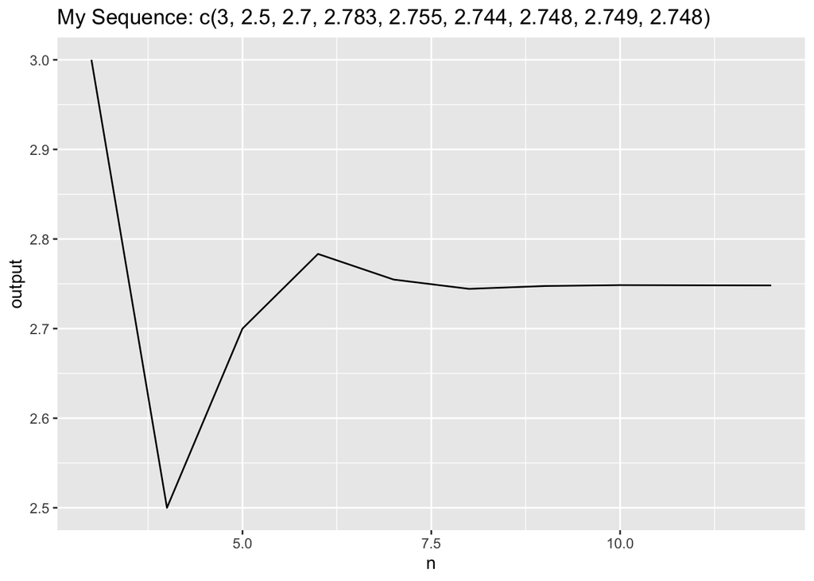

## 1.3 Common Requirements

- Use `hw04p` as the first part of your package name followed by your GitHub ID (as modified to make a compliant package name)
- Ensure your name and GitHub ID are in the package READ.ME file.
- The functions must include error checking and terminate if any of the input arguments are not in compliance.

# 2 Extra Credit (1 pt)

- Watch or listen to the RStudio Conf2020 KeyNote address by Jenny Bryan called [*Object of type ‘closure’ is not subsettable*](https://rstudio.com/resources/rstudioconf-2020/object-of-type-closure-is-not-subsettable/) and answer the following questions as part of your submission on Canvas:
1. Which of the methods do you think will be most useful for you and why?
2. What do you think of the RStudio effort to add hints to error messages?